# 尿镉与桥本甲状腺炎的相关性分析：基于NHANES 2007-2012

gengsiyuan

2026-07-04

# 一、研究背景

桥本甲状腺炎（Hashimoto’s thyroiditis, HT）是最常见的自身免疫性甲状腺疾病，其发病机制尚未完全阐明。近年来，环境污染物暴露与自身免疫性疾病的关系日益受到关注。镉（Cadmium）是一种广泛存在的环境重金属污染物，具有免疫毒性作用。本研究旨在利用美国国家健康与营养调查（NHANES）2007-2012年的数据，探讨尿镉水平与桥本甲状腺炎之间的关联。

# 二、研究问题

1.独立关联：校正多重混杂后，校正尿镉浓度与桥本甲状腺炎患病风险是否存在独立正向关联；

2.剂量-反应趋势：将尿镉按加权四分位数分为4组，一是与最低暴露组Q1相比，Q2、Q3、Q4 组 HT 患病风险是否显著升高；二是尿镉暴露等级与HT风险是否存在线性递增趋势;

3.易感人群与效应修饰：尿镉-HT关联是否存在性别、年龄分层差异；性别、年龄是否存在显著交互修饰作用。

# 三、数据来源

本研究数据来源于美国国家健康与营养调查（National Health and Nutrition Examination Survey, NHANES）2007-2012年三个周期（2007-2008、2009-2010、2011-2012）的数据。NHANES是由美国国家卫生统计中心（NCHS）开展的全国性横断面调查，采用复杂的多阶段分层整群抽样设计，对美国非住院居民的健康状况进行代表性评估。

## 3.1 数据导入

```r
# 加载包
library(nhanesA)
library(tidyverse)
library(writexl)
library(survey)
library(naniar)
# 导入2007-2008年数据
thyroid_0708 <- nhanes("THYROD_E")
urine_cadmium_0708 <- nhanes("UHM_E")
demo_0708   <- nhanes("DEMO_E")
smoke_0708  <- nhanes("SMQ_E")
bmx_0708    <- nhanes("BMX_E")
bpq_0708    <- nhanes("BPQ_E")

# 导入2009-2010年数据
thyroid_0910 <- nhanes("THYROD_F")
urine_cadmium_0910 <- nhanes("UHM_F")
demo_0910   <- nhanes("DEMO_F")
smoke_0910  <- nhanes("SMQ_F")
bmx_0910    <- nhanes("BMX_F")
bpq_0910    <- nhanes("BPQ_F")

# 导入2011-2012年数据
thyroid_1112 <- nhanes("THYROD_G")
urine_cadmium_1112 <- nhanes("UHM_G")
demo_1112   <- nhanes("DEMO_G")
smoke_1112  <- nhanes("SMQ_G")
bmx_1112    <- nhanes("BMX_G")
bpq_1112    <- nhanes("BPQ_G")
```

## 3.2 变量筛选与合并

```r
# 定义核心变量
demo_required <- c("SEQN", "WTMEC2YR", "RIDAGEYR", "RIAGENDR", "RIDRETH1",
                   "INDFMPIR", "DMDEDUC2", "SDMVSTRA", "SDMVPSU")
bmx_required <- c("SEQN", "BMXBMI")
smoke_required <- c("SEQN", "SMQ020")
bpq_required <- c("SEQN", "BPQ020")
thyroid_required <- c("SEQN", "LBXTPO", "LBXATG")
cadmium_required <- c("SEQN", "URXUCD", "URXUCR")

# 筛选变量
demo_0708_sel <- demo_0708 %>% select(all_of(demo_required))
demo_0910_sel <- demo_0910 %>% select(all_of(demo_required))
demo_1112_sel <- demo_1112 %>% select(all_of(demo_required))
bmx_0708_sel <- bmx_0708 %>% select(all_of(bmx_required))
bmx_0910_sel <- bmx_0910 %>% select(all_of(bmx_required))
bmx_1112_sel <- bmx_1112 %>% select(all_of(bmx_required))
smoke_0708_sel <- smoke_0708 %>% select(all_of(smoke_required))
smoke_0910_sel <- smoke_0910 %>% select(all_of(smoke_required))
smoke_1112_sel <- smoke_1112 %>% select(all_of(smoke_required))
bpq_0708_sel <- bpq_0708 %>% select(all_of(bpq_required))
bpq_0910_sel <- bpq_0910 %>% select(all_of(bpq_required))
bpq_1112_sel <- bpq_1112 %>% select(all_of(bpq_required))
thyroid_0708_sel <- thyroid_0708 %>% select(all_of(thyroid_required))
thyroid_0910_sel <- thyroid_0910 %>% select(all_of(thyroid_required))
thyroid_1112_sel <- thyroid_1112 %>% select(all_of(thyroid_required))
cadmium_0708_sel <- urine_cadmium_0708 %>% select(all_of(cadmium_required))
cadmium_0910_sel <- urine_cadmium_0910 %>% select(all_of(cadmium_required))
cadmium_1112_sel <- urine_cadmium_1112 %>% select(all_of(cadmium_required))

# 纵向合并三个周期
demo_all    <- bind_rows(demo_0708_sel, demo_0910_sel, demo_1112_sel)
bmx_all     <- bind_rows(bmx_0708_sel, bmx_0910_sel, bmx_1112_sel)
smoke_all   <- bind_rows(smoke_0708_sel, smoke_0910_sel, smoke_1112_sel)
bpq_all     <- bind_rows(bpq_0708_sel, bpq_0910_sel, bpq_1112_sel)
thyroid_all <- bind_rows(thyroid_0708_sel, thyroid_0910_sel, thyroid_1112_sel)
cadmium_all <- bind_rows(cadmium_0708_sel, cadmium_0910_sel, cadmium_1112_sel)

# 横向合并
data_merged <- cadmium_all %>%
  left_join(thyroid_all, by = "SEQN") %>%
  left_join(demo_all, by = "SEQN") %>%
  left_join(bmx_all, by = "SEQN") %>%
  left_join(smoke_all, by = "SEQN") %>%
  left_join(bpq_all, by = "SEQN")

# 计算6年权重
data_merged <- data_merged %>%
  mutate(wt_6yr = WTMEC2YR/3)
```

## 3.3 研究对象纳入与排除标准

### 纳入标准

1. 年龄 ≥ 20 周岁；
2. 具有完整的尿镉（URXUCD）、尿肌酐（URXUCR）、甲状腺过氧化物酶抗体（LBXTPO）及甲状腺球蛋白抗体（LBXATG）检测数据；
3. 具有有效的抽样权重（WTMEC2YR）。

### 排除标准

1. 年龄 < 20 周岁；
2. 核心变量（尿镉、甲状腺抗体）存在任一缺失；
3. 抽样权重缺失或为零。

### 最终纳入样本

本研究初始纳入年龄 ≥ 20 周岁且具有核心检测指标的个体共 5,768 例，经完整病例分析剔除存在缺失值的样本后，最终纳入**4,638**例研究对象进行分析。

# 四、变量说明

## 4.1 结局变量（桥本甲状腺炎）

桥本甲状腺炎的定义基于血清甲状腺自身抗体水平： - **甲状腺过氧化物酶抗体（TPOAb）> 9 IU/mL** 或 **甲状腺球蛋白抗体（TgAb）> 4 IU/mL** 定义为阳性 - 两者均阴性且均有检测值定义为阴性

## 4.2 暴露变量（尿镉）

尿镉浓度经尿肌酐校正，计算公式为： - **校正尿镉（μg/g 肌酐）= 尿镉（μg/L）/ 尿肌酐（mg/dL）× 1000**

## 4.3 协变量

本研究纳入的协变量包括： - **连续变量**：年龄、身体质量指数（BMI）、贫困收入比（PIR） - **分类变量**：性别（男/女）、种族（白人/黑人/西班牙裔/其他）、教育程度（低于高中/高中/大学及以上）、吸烟状况（从不吸烟/吸烟）、高血压（有/无）

# 五、研究方法

## 5.1 数据清洗

```r
# 筛选年龄≥20岁成人
data_clean <- data_merged %>% filter(RIDAGEYR >= 20)

# 特殊编码转NA
data_clean <- data_clean %>%
  mutate(across(where(is.numeric), ~ na_if(na_if(na_if(., 777), 888), 999)))

# 定义结局和尿镉校正
data_clean <- data_clean %>%
  mutate(
    hashimoto = case_when(
      LBXTPO > 9 | LBXATG > 4 ~ 1,
      !is.na(LBXTPO) & !is.na(LBXATG) ~ 0,
      TRUE ~ NA_real_
    ),
    URXUCD_cr = URXUCD / URXUCR * 1000
  )

# 转换分类协变量
data_clean <- data_clean %>%
  mutate(
    sex = factor(RIAGENDR, levels = c("Male", "Female"), labels = c("男", "女")),
    race = factor(
      case_when(
        RIDRETH1 %in% c("Mexican American", "Other Hispanic", 3, 4) ~ "西班牙裔",
        RIDRETH1 %in% c("Non-Hispanic White", 1) ~ "白人",
        RIDRETH1 %in% c("Non-Hispanic Black", 2) ~ "黑人",
        TRUE ~ "其他"
      ),
      levels = c("白人", "黑人", "西班牙裔", "其他")
    ),
    education = factor(
      case_when(
        grepl("Less than 9th|Less Than 9th|9-11th grade", DMDEDUC2, ignore.case = TRUE) ~ "低于高中",
        grepl("High school graduate|High School Grad|GED", DMDEDUC2, ignore.case = TRUE) ~ "高中",
        grepl("College graduate|Some college|AA degree", DMDEDUC2, ignore.case = TRUE) ~ "大学及以上",
        TRUE ~ NA_character_
      ),
      levels = c("低于高中", "高中", "大学及以上")
    ),
    smoke = factor(
      case_when(
        SMQ020 %in% c("No", 2) ~ "从不吸烟",
        SMQ020 %in% c("Yes", 1) ~ "吸烟",
        TRUE ~ NA_character_
      ),
      levels = c("从不吸烟", "吸烟")
    ),
    hypertension = factor(
      case_when(
        BPQ020 == "Yes" ~ "有",
        BPQ020 == "No" ~ "无",
        TRUE ~ NA_character_
      ),
      levels = c("有", "无")
    )
  )

# 删除缺失值
data_final <- data_clean %>%
  drop_na(
    URXUCD_cr, hashimoto, wt_6yr,
    RIDAGEYR, sex, race, education, smoke, hypertension,
    BMXBMI, INDFMPIR
  )

# 定义分组变量
data_final <- data_final %>%
  mutate(hashimoto_grp = factor(hashimoto,
                                levels = 0:1,
                                labels = c("桥本阴性", "桥本阳性")))

# 保存清洗后数据
writexl::write_xlsx(data_final, "NHANES_2007_2012_urine_cadmium_final_clean.xlsx")
```

## 5.2 统计分析方法

本研究采用以下统计方法：

1. **加权描述性分析**：连续变量以中位数（P25，P75）描述，分类变量以加权频数（加权百分比）描述；
2. **组间比较**：根据变量正态性选择加权t检验或加权Wilcoxon秩和检验（连续变量），加权卡方检验（分类变量）；
3. **多因素Logistic回归**：构建三个模型评估尿镉与桥本甲状腺炎的关联；
4. **剂量-反应分析**：将尿镉采用加权四分位数划分为 4 个暴露组，以最低四分位数 Q1 为参照计算各组OR及95%CI，并开展线性趋势检验，同时分析组间效应与整体剂量递增趋势；
5. **亚组分析**：按年龄（<45岁 vs ≥45岁）和性别进行分层分析；
6. **交互作用检验**：检验年龄和性别对尿镉-桥本关联的交互作用。

所有分析均考虑NHANES复杂抽样设计，使用抽样权重、分层变量和初级抽样单元。

## 5.3 加权设计

```r
library(survey)
library(gtsummary)
library(dplyr)
library(flextable)
```

```r
library(ggplot2)
library(broom)
library(tidyr)

# 构建加权设计
svy_design <- svydesign(
  id = ~SDMVPSU,
  strata = ~SDMVSTRA,
  weights = ~wt_6yr,
  data = data_final,
  nest = TRUE
)
```

# 六、研究结果

## 6.1 正态性检验

```r
cont_vars <- c("URXUCD_cr", "RIDAGEYR", "BMXBMI", "INDFMPIR")
norm_decision <- data.frame(
  variable = cont_vars,
  skewness = NA,
  kurtosis = NA,
  decision = NA
)

for (i in seq_along(cont_vars)) {
  v <- cont_vars[i]
  dat <- svy_design$variables
  w <- weights(svy_design)
  x <- dat[[v]]
  valid <- !is.na(x) & !is.na(w) & !is.na(dat$hashimoto)
  x <- x[valid]
  w <- w[valid]
  w <- w / sum(w)
  mu <- sum(w * x)
  sigma <- sqrt(sum(w * (x - mu)^2))
  skew <- sum(w * ((x - mu) / sigma)^3)
  kurt <- sum(w * ((x - mu) / sigma)^4) - 3
  norm_decision$skewness[i] <- round(skew, 3)
  norm_decision$kurtosis[i] <- round(kurt, 3)
  if (abs(skew) > 1 || abs(kurt) > 2) {
    norm_decision$decision[i] <- "偏态 → 加权秩和检验"
  } else {
    norm_decision$decision[i] <- "近似正态 → 加权t检验"
  }
}

knitr::kable(norm_decision, caption = "表1. 连续变量正态性检验结果")
```

表1. 连续变量正态性检验结果

| variable | skewness | kurtosis | decision |
| --- | --- | --- | --- |
| URXUCD_cr | 6.649 | 83.279 | 偏态 → 加权秩和检验 |
| RIDAGEYR | 0.255 | -0.844 | 近似正态 → 加权t检验 |
| BMXBMI | 1.289 | 3.134 | 偏态 → 加权秩和检验 |
| INDFMPIR | -0.104 | -1.450 | 近似正态 → 加权t检验 |

## 6.2 组间比较

```r
# 尿镉组间比较（加权秩和检验）
urine_test <- svyranktest(URXUCD_cr ~ hashimoto, design = svy_design)

# 分类变量组间比较（加权卡方检验）
cat_vars <- c("sex", "race", "education", "smoke", "hypertension")
chisq_results <- lapply(cat_vars, function(var) {
  formula <- as.formula(paste("~", var, "+ hashimoto"))
  test <- svychisq(formula, design = svy_design, statistic = "F")
  data.frame(
    variable = var,
    p_value = test$p.value,
    statistic = round(test$statistic, 2)
  )
})
chisq_table <- bind_rows(chisq_results)

# 连续变量组间比较
age_test <- svyttest(RIDAGEYR ~ hashimoto, design = svy_design)
bmi_test <- svyranktest(BMXBMI ~ hashimoto, design = svy_design)
pir_test <- svyttest(INDFMPIR ~ hashimoto, design = svy_design)

# 提取P值
age_p <- age_test$p.value
bmi_p <- bmi_test$p.value
pir_p <- pir_test$p.value
cad_p <- urine_test$p.value

cat("尿镉 P值:", format(cad_p, scientific = FALSE, digits = 4), "\n")
```

```
## 尿镉 P值: 0.000001775
```

```r
cat("年龄 P值:", format(age_p, scientific = FALSE, digits = 4), "\n")
```

```
## 年龄 P值: 0.000000002024
```

```r
cat("BMI P值:", format(bmi_p, scientific = FALSE, digits = 4), "\n")
```

```
## BMI P值: 0.3613
```

```r
cat("贫困收入比 P值:", format(pir_p, scientific = FALSE, digits = 4), "\n")
```

```
## 贫困收入比 P值: 0.01034
```

## 6.3 加权基线特征

### 表2. 研究人群加权基线特征及组间比较

```r
# 创建基础表格
tbl_base <- tbl_svysummary(
  svy_design,
  by = hashimoto_grp,
  include = c(RIDAGEYR, BMXBMI, INDFMPIR, URXUCD_cr,
              sex, race, education, smoke, hypertension),
  statistic = list(
    all_continuous() ~ "{median} ({p25}, {p75})",
    all_categorical() ~ "{n} ({p}%)"
  ),
  digits = list(all_continuous() ~ 1, all_categorical() ~ c(0, 1)),
  label = list(
    RIDAGEYR ~ "年龄 (岁)",
    BMXBMI ~ "身体质量指数 (kg/m²)",
    INDFMPIR ~ "贫困收入比",
    URXUCD_cr ~ "尿镉 (μg/g 肌酐)",
    sex ~ "性别",
    race ~ "种族",
    education ~ "教育程度",
    smoke ~ "吸烟状况",
    hypertension ~ "高血压"
  )
) %>%
  modify_header(all_stat_cols() ~ "**{level} (加权 n = {n})**") %>%
  bold_labels()

# ========== 定义P值数据框 ==========
p_df <- data.frame(
  variable = c("RIDAGEYR", "BMXBMI", "INDFMPIR", "URXUCD_cr",
               "sex", "race", "education", "smoke", "hypertension"),
  p_val = c(age_p, bmi_p, pir_p, cad_p,
            chisq_table$p_value[chisq_table$variable == "sex"],
            chisq_table$p_value[chisq_table$variable == "race"],
            chisq_table$p_value[chisq_table$variable == "education"],
            chisq_table$p_value[chisq_table$variable == "smoke"],
            chisq_table$p_value[chisq_table$variable == "hypertension"])
)

# 添加P值（直接生成最终表2）
tbl_final <- tbl_base %>%
  modify_table_body(
    ~ .x %>%
      mutate(p.value = p_df$p_val[match(variable, p_df$variable)]) %>%
      group_by(variable) %>%
      mutate(p.value = ifelse(row_number() == 1, p.value, NA)) %>%
      ungroup()
  ) %>%
  modify_fmt_fun(
    p.value ~ function(x) {
      ifelse(is.na(x), "",
             ifelse(x < 0.0001, "<0.0001",
                    sprintf("%.4f", round(x, 4))))
    }
  ) %>%
  modify_header(p.value ~ "**P值**") %>%
  modify_caption("表2. 研究人群加权基线特征及组间比较") %>%
  bold_labels()

tbl_final
```

表2. 研究人群加权基线特征及组间比较

| **Characteristic** | **桥本阴性 (加权 n = 51583821.749582)**<sup>1</sup> | **桥本阳性 (加权 n = 9621435.29640833)**<sup>1</sup> | **P值** |
| --- | --- | --- | --- |
| 年龄 (岁) | 45.0 (32.0, 57.0) | 51.0 (40.0, 63.0) | <0.0001 |
| 身体质量指数 (kg/m²) | 27.4 (24.1, 31.9) | 27.2 (23.6, 31.2) | 0.3613 |
| 贫困收入比 | 2.9 (1.4, 5.0) | 3.5 (1.8, 5.0) | 0.0103 |
| 尿镉 (μg/g 肌酐) | 2.2 (1.2, 4.0) | 2.9 (1.7, 5.2) | <0.0001 |
| 性别 |  |  | <0.0001 |
| 男 | 26,441,549 (51.3%) | 3,274,112 (34.0%) |  |
| 女 | 25,142,272 (48.7%) | 6,347,324 (66.0%) |  |
| 种族 |  |  | <0.0001 |
| 白人 | 35,197,266 (68.2%) | 7,476,639 (77.7%) |  |
| 黑人 | 5,985,065 (11.6%) | 418,903 (4.4%) |  |
| 西班牙裔 | 6,998,906 (13.6%) | 1,078,185 (11.2%) |  |
| 其他 | 3,402,585 (6.6%) | 647,708 (6.7%) |  |
| 教育程度 |  |  | 0.0437 |
| 低于高中 | 9,530,462 (18.5%) | 1,288,859 (13.4%) |  |
| 高中 | 11,458,743 (22.2%) | 2,220,761 (23.1%) |  |
| 大学及以上 | 30,594,617 (59.3%) | 6,111,814 (63.5%) |  |
| 吸烟状况 |  |  | 0.2102 |
| 从不吸烟 | 27,739,823 (53.8%) | 5,525,139 (57.4%) |  |
| 吸烟 | 23,843,999 (46.2%) | 4,096,296 (42.6%) |  |
| 高血压 |  |  | 0.6033 |
| 有 | 15,264,188 (29.6%) | 2,973,201 (30.9%) |  |
| 无 | 36,319,633 (70.4%) | 6,648,235 (69.1%) |  |

<sup>1</sup> Median (Q1, Q3); n (%)

## 6.4 可视化分析

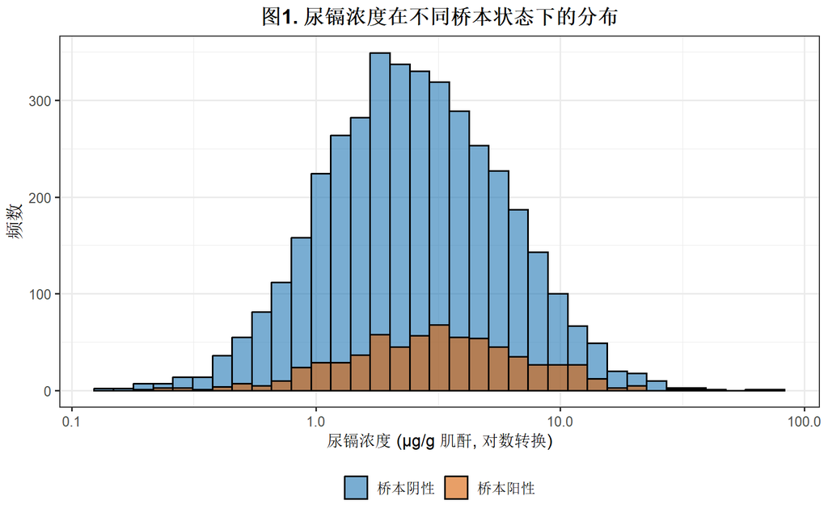

```r
# 图1：尿镉分布直方图
p1 <- ggplot(data_final, aes(x = URXUCD_cr, fill = hashimoto_grp)) +
  geom_histogram(alpha = 0.6, position = "identity", bins = 35, color = "black") +
  scale_x_log10() +
  scale_fill_manual(values = c("#1f77b4", "#d95f02")) +
  labs(title = "图1. 尿镉浓度在不同桥本状态下的分布",
       x = "尿镉浓度 (μg/g 肌酐, 对数转换)",
       y = "频数", fill = "组别") +
  theme_bw(base_size = 12) +
  theme(plot.title = element_text(hjust = 0.5, face = "bold", size = 14),
        legend.position = "bottom", legend.title = element_blank())
p1
```

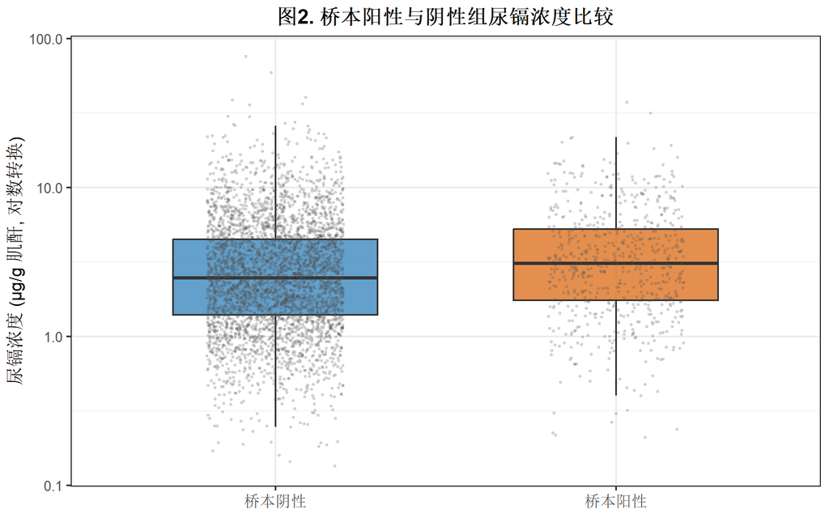

```r
# 图2：尿镉组间箱线图
set.seed(123)
p2 <- ggplot(data_final, aes(x = hashimoto_grp, y = URXUCD_cr, fill = hashimoto_grp)) +
  geom_boxplot(alpha = 0.7, width = 0.6, outlier.shape = NA) +
  geom_jitter(width = 0.2, alpha = 0.15, size = 0.6, color = "gray30") +
  scale_y_log10() +
  scale_fill_manual(values = c("#1f77b4", "#d95f02")) +
  labs(title = "图2. 桥本阳性与阴性组尿镉浓度比较",
       x = NULL, y = "尿镉浓度 (μg/g 肌酐, 对数转换)") +
  theme_bw(base_size = 12) +
  theme(plot.title = element_text(hjust = 0.5, face = "bold", size = 14),
        legend.position = "none", axis.text.x = element_text(size = 11))
p2
```

## 6.5 多因素Logistic回归

```r
# 新增log10转换后的尿镉变量
svy_design$variables$log_URXUCD_cr <- log10(svy_design$variables$URXUCD_cr)

# 模型1：粗模型
m1 <- svyglm(hashimoto ~ log_URXUCD_cr,
             design = svy_design,
             family = quasibinomial)

# 模型2：调整人口学+社会经济
m2 <- svyglm(hashimoto ~ log_URXUCD_cr + RIDAGEYR + sex + race + education + INDFMPIR,
             design = svy_design,
             family = quasibinomial)

# 模型3：完全调整
m3 <- svyglm(hashimoto ~ log_URXUCD_cr + RIDAGEYR + sex + race + education + INDFMPIR +
               smoke + hypertension + BMXBMI,
             design = svy_design,
             family = quasibinomial)

# 提取结果
tidy_m1 <- tidy(m1, conf.int = TRUE, exponentiate = TRUE) %>% filter(term == "log_URXUCD_cr")
tidy_m2 <- tidy(m2, conf.int = TRUE, exponentiate = TRUE) %>% filter(term == "log_URXUCD_cr")
tidy_m3 <- tidy(m3, conf.int = TRUE, exponentiate = TRUE) %>% filter(term == "log_URXUCD_cr")

logistic_results <- bind_rows(
  mutate(tidy_m1, Model = "模型1 (粗模型)"),
  mutate(tidy_m2, Model = "模型2 (+人口学+社会经济)"),
  mutate(tidy_m3, Model = "模型3 (+生活方式/慢性病)")
) %>%
  select(Model, estimate, conf.low, conf.high, p.value) %>%
  rename(OR = estimate, CI_lower = conf.low, CI_upper = conf.high, P_value = p.value) %>%
  mutate(across(c(OR, CI_lower, CI_upper), ~ round(., 3)),
         P_value = round(P_value, 4))

knitr::kable(logistic_results, caption = "表3.尿镉与桥本甲状腺炎的多因素Logistic回归")
```

表3.尿镉与桥本甲状腺炎的多因素Logistic回归

| Model | OR | CI_lower | CI_upper | P_value |
| --- | --- | --- | --- | --- |
| 模型1 (粗模型) | 2.289 | 1.649 | 3.177 | 0.0000 |
| 模型2 (+人口学+社会经济) | 1.402 | 0.991 | 1.984 | 0.0561 |
| 模型3 (+生活方式/慢性病) | 1.538 | 1.050 | 2.253 | 0.0280 |

## 6.6 剂量-反应分析

```r
# 加权四分位数分组
quant_obj <- svyquantile(~URXUCD_cr, design = svy_design,
                         quantiles = c(0, 0.25, 0.5, 0.75, 1),
                         na.rm = TRUE)
quantiles <- as.numeric(quant_obj$URXUCD_cr[,1])

svy_design$variables$urine_q <- cut(
  svy_design$variables$URXUCD_cr,
  breaks = quantiles,
  include.lowest = TRUE,
  labels = c("Q1", "Q2", "Q3", "Q4")
)

# 四分位数模型
formula_q <- as.formula(
  hashimoto ~ urine_q + RIDAGEYR + sex + race + education +
    INDFMPIR + smoke + hypertension + BMXBMI
)
fit_q <- svyglm(formula_q, design = svy_design, family = quasibinomial)
tidy_q <- tidy(fit_q, conf.int = TRUE, exponentiate = TRUE) %>%
  filter(grepl("urine_q", term))

# 线性趋势检验
svy_design$variables$urine_q_num <- as.numeric(svy_design$variables$urine_q)
formula_trend <- update(formula_q, . ~ . - urine_q + urine_q_num)
fit_trend <- svyglm(formula_trend, design = svy_design, family = quasibinomial)
tidy_trend <- tidy(fit_trend, conf.int = TRUE, exponentiate = TRUE) %>%
  filter(term == "urine_q_num")

# 汇总表
q_results <- tidy_q %>%
  mutate(
    OR_CI = paste0(round(estimate, 2), " (", round(conf.low, 2), "-", round(conf.high, 2), ")"),
    P = round(p.value, 4),
    Exposure = case_when(
      term == "urine_qQ2" ~ "Q2",
      term == "urine_qQ3" ~ "Q3",
      term == "urine_qQ4" ~ "Q4",
      TRUE ~ term
    )
  ) %>%
  select(Exposure, OR_CI, P)

trend_line <- data.frame(
  Exposure = "线性趋势（每升高1个四分位等级）",
  OR_CI = paste0(
    round(tidy_trend$estimate, 2), " (",
    round(tidy_trend$conf.low, 2), "-",
    round(tidy_trend$conf.high, 2), ")"
  ),
  P = round(tidy_trend$p.value, 4)
)

dose_response_table <- bind_rows(q_results, trend_line)
knitr::kable(dose_response_table, caption = "表4.尿镉与桥本甲状腺炎的剂量-反应分析")
```

表4.尿镉与桥本甲状腺炎的剂量-反应分析

| Exposure | OR_CI | P |
| --- | --- | --- |
| Q2 | 0.97 (0.67-1.4) | 0.8793 |
| Q3 | 1.26 (0.85-1.87) | 0.2430 |
| Q4 | 1.47 (0.99-2.2) | 0.0577 |
| 线性趋势（每升高1个四分位等级） | 1.16 (1.03-1.31) | 0.0175 |

*注：Q1为参照组；趋势检验将四分位等级（1、2、3、4）作为连续变量纳入模型。*

## 6.7 亚组分析

```r
# 创建年龄分组
svy_design$variables$age_group <- ifelse(svy_design$variables$RIDAGEYR < 45, "<45岁", "≥45岁")
svy_design$variables$age_group <- factor(svy_design$variables$age_group,
                                         levels = c("<45岁", "≥45岁"))

# 构建公式函数
build_formula <- function(sub_ds) {
  base_vars <- c("urine_q_num")
  candidates <- c("RIDAGEYR", "sex", "race", "education", "INDFMPIR", "smoke", "hypertension", "BMXBMI")
  keep_vars <- base_vars
  for (v in candidates) {
    if (v %in% names(sub_ds$variables)) {
      val <- sub_ds$variables[[v]]
      if (is.factor(val) || is.character(val)) {
        if (length(unique(na.omit(val))) > 1) {
          keep_vars <- c(keep_vars, v)
        }
      } else {
        keep_vars <- c(keep_vars, v)
      }
    }
  }
  formula_str <- paste("hashimoto ~", paste(keep_vars, collapse = " + "))
  return(as.formula(formula_str))
}

# 年龄分层
age_levels <- levels(svy_design$variables$age_group)
age_list_cont <- list()
for (g in age_levels) {
  sub_ds <- subset(svy_design, age_group == g)
  sub_ds <- subset(sub_ds,
                   !is.na(hashimoto) & !is.na(RIDAGEYR) & !is.na(race) & !is.na(education) &
                     !is.na(INDFMPIR) & !is.na(smoke) & !is.na(hypertension) & !is.na(BMXBMI))
  formula_cont <- build_formula(sub_ds)
  fit <- tryCatch(
    svyglm(formula_cont, design = sub_ds, family = quasibinomial),
    error = function(e) { return(NULL) }
  )
  if (is.null(fit)) next
  tidy_fit <- tidy(fit, conf.int = TRUE, exponentiate = TRUE) %>%
    filter(term == "urine_q_num") %>%
    mutate(Subgroup = paste0("年龄：", g))
  age_list_cont[[g]] <- tidy_fit
}
age_df_cont <- bind_rows(age_list_cont)

# 性别分层
sex_levels <- levels(svy_design$variables$sex)
sex_list <- list()
for (g in sex_levels) {
  sub_ds <- subset(svy_design, sex == g)
  sub_ds <- subset(sub_ds,
                   !is.na(hashimoto) & !is.na(RIDAGEYR) & !is.na(race) & !is.na(education) &
                     !is.na(INDFMPIR) & !is.na(smoke) & !is.na(hypertension) & !is.na(BMXBMI))
  if (nrow(sub_ds) < 30) next
  cox_vars <- c("RIDAGEYR", "race", "education", "INDFMPIR", "smoke", "hypertension", "BMXBMI")
  keep_vars <- "urine_q_num"
  for (v in cox_vars) {
    if (v %in% names(sub_ds$variables)) {
      val <- sub_ds$variables[[v]]
      if (is.numeric(val) || is.integer(val)) {
        keep_vars <- c(keep_vars, v)
      } else if (is.factor(val) || is.character(val)) {
        if (length(unique(na.omit(val))) > 1) {
          keep_vars <- c(keep_vars, v)
        }
      }
    }
  }
  formula_str <- paste("hashimoto ~", paste(keep_vars, collapse = " + "))
  formula_sub <- as.formula(formula_str)
  fit <- tryCatch(
    svyglm(formula_sub, design = sub_ds, family = quasibinomial),
    error = function(e) { return(NULL) }
  )
  if (is.null(fit)) next
  tidy_fit <- tidy(fit, conf.int = TRUE, exponentiate = TRUE) %>%
    filter(term == "urine_q_num") %>%
    mutate(Subgroup = paste0("性别：", g))
  sex_list[[g]] <- tidy_fit
}
sex_df <- bind_rows(sex_list)

# 合并亚组结果
subgroup_results <- bind_rows(
  sex_df %>% mutate(Subgroup = as.character(Subgroup)),
  age_df_cont %>% mutate(Subgroup = as.character(Subgroup))
) %>%
  mutate(
    OR_CI = paste0(round(estimate, 2), " (", round(conf.low, 2), "-", round(conf.high, 2), ")"),
    P = round(p.value, 4)
  ) %>%
  select(Subgroup, OR_CI, P)

knitr::kable(subgroup_results, caption = "表5. 亚组分层分析结果")
```

表5. 亚组分层分析结果

| Subgroup | OR_CI | P |
| --- | --- | --- |
| 性别：男 | 0.94 (0.76-1.17) | 0.5636 |
| 性别：女 | 1.32 (1.11-1.57) | 0.0024 |
| 年龄：<45岁 | 1.09 (0.9-1.31) | 0.3620 |
| 年龄：≥45岁 | 1.15 (0.99-1.34) | 0.0637 |

## 6.8 交互作用检验

```r
library(stringr)

svy_design_inter <- update(svy_design,
                           age_group_num = ifelse(age_group == "≥45岁", 1, 0),
                           sex_num = ifelse(sex == "女", 1, 0))

# 年龄交互
interaction_age <- svyglm(
  hashimoto ~ urine_q_num * age_group_num +
    sex + race + education + INDFMPIR + smoke + hypertension + BMXBMI,
  design = svy_design_inter,
  family = quasibinomial
)
tidy_age_interaction <- tidy(interaction_age, conf.int = TRUE, exponentiate = TRUE)
age_inter_p <- tidy_age_interaction %>%
  filter(str_detect(term, "urine_q_num:age_group_num")) %>%
  pull(p.value)

# 性别交互
interaction_sex <- svyglm(
  hashimoto ~ urine_q_num * sex_num +
    RIDAGEYR + race + education + INDFMPIR + smoke + hypertension + BMXBMI,
  design = svy_design_inter,
  family = quasibinomial
)
tidy_sex_interaction <- tidy(interaction_sex, conf.int = TRUE, exponentiate = TRUE)
sex_inter_p <- tidy_sex_interaction %>%
  filter(str_detect(term, "urine_q_num:sex_num")) %>%
  pull(p.value)

format_p <- function(p) {
  if (is.na(p)) return("NA")
  if (p < 0.001) return("<0.001")
  if (p < 0.01) return(sprintf("%.3f", p))
  return(sprintf("%.4f", p))
}

interaction_results <- data.frame(
  Interaction = c("年龄 × 尿镉", "性别 × 尿镉"),
  P_value = c(format_p(age_inter_p), format_p(sex_inter_p))
)
knitr::kable(interaction_results, caption = "表6. 交互作用检验结果")
```

表6. 交互作用检验结果

| Interaction | P_value |
| --- | --- |
| 年龄 × 尿镉 | 0.3557 |
| 性别 × 尿镉 | 0.008 |

## 6.9 亚组森林图

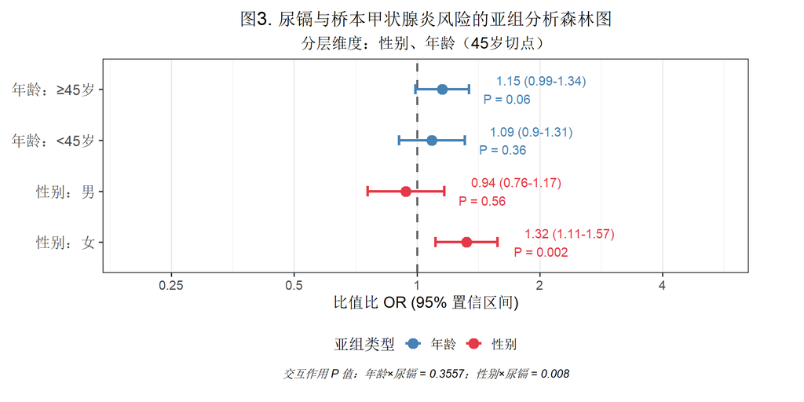

```r
all_sub_res <- bind_rows(sex_df, age_df_cont)

forest_input <- all_sub_res %>%
  rename(
    Subgroup = Subgroup,
    OR = estimate,
    CI_low = conf.low,
    CI_high = conf.high
  ) %>%
  mutate(
    Group = ifelse(str_detect(Subgroup, "性别"), "性别", "年龄"),
    Subgroup = case_when(
      Subgroup == "≥45岁" ~ "年龄：≥45岁",
      Subgroup == "<45岁" ~ "年龄：<45岁",
      TRUE ~ Subgroup
    ),
    Subgroup = factor(Subgroup,
                      levels = c("性别：女", "性别：男",
                                 "年龄：<45岁", "年龄：≥45岁")),
    p_label = case_when(
      p.value < 0.001 ~ "P < 0.001",
      p.value < 0.01  ~ paste0("P = ", round(p.value, 3)),
      TRUE            ~ paste0("P = ", round(p.value, 2))
    ),
    label_text = paste0(
      round(OR, 2), " (", round(CI_low, 2), "-", round(CI_high, 2), ")\n",
      p_label
    )
  )

p_forest <- ggplot(forest_input, aes(x = OR, y = Subgroup, color = Group)) +
  geom_vline(xintercept = 1, linetype = "dashed", color = "gray40", linewidth = 1) +
  geom_errorbar(aes(xmin = CI_low, xmax = CI_high),
                width = 0.2, orientation = "y", linewidth = 1.2) +
  geom_point(size = 4) +
  geom_text(aes(label = label_text, x = CI_high),
            hjust = -0.3, size = 4, show.legend = FALSE) +
  scale_x_log10(breaks = c(0.25, 0.5, 1, 2, 4),
                labels = c("0.25", "0.5", "1", "2", "4"),
                limits = c(0.2, 5.5)) +
  scale_color_manual(values = c("steelblue", "#e63946")) +
  labs(
    title = "图3. 尿镉与桥本甲状腺炎风险的亚组分析森林图",
    subtitle = "分层维度：性别、年龄（45岁切点）",
    x = "比值比 OR (95% 置信区间)",
    y = NULL,
    color = "亚组类型",
    caption = paste0(
      "交互作用 P 值：年龄×尿镉 = ", format_p(age_inter_p),
      "；性别×尿镉 = ", format_p(sex_inter_p)
    )
  ) +
  theme_bw(base_size = 14) +
  theme(
    panel.grid.major.y = element_blank(),
    plot.title = element_text(hjust = 0.5),
    plot.subtitle = element_text(hjust = 0.5),
    plot.caption = element_text(hjust = 0.5, size = 10, face = "italic"),
    legend.position = "bottom",
    axis.text.y = element_text(size = 13),
    plot.margin = margin(10, 50, 20, 10)
  )
p_forest
```

# 七、讨论

## 7.1 主要发现

本研究基于NHANES 2007-2012年数据，探讨了尿镉水平与桥本甲状腺炎之间的关联。主要发现如下：

1. **基线特征**：桥本阳性组与阴性组相比，年龄更大、尿镉水平更高、女性比例更高（均P<0.001）；两组在教育程度（P=0.044）和贫困收入比（P=0.010）方面也有显著差异；BMI、吸烟状况和高血压在两组间无显著差异（P>0.05）。
2. **多因素分析**：经完全校正模型显示，**log₁₀转换后的校正尿镉每上升1个单位**，桥本甲状腺炎患病风险升高 **53.8%**（OR=1.538，95%CI：1.050-2.253）。
3. **剂量-反应关系**：尿镉水平与桥本甲状腺炎风险呈显著线性趋势（P for trend < 0.05）。
4. **亚组分析**：
   - **性别**：女性群体中尿镉与HT的关联显著（OR=1.32，95%CI: 1.11-1.57，P=0.002），男性群体中未观察到显著关联（OR=0.94，95%CI: 0.76-1.17，P=0.564）。
   - **年龄**：≥45岁组呈边缘显著（OR=1.15，95%CI: 0.99-1.34，P=0.064），<45岁组未观察到显著关联（OR=1.09，95%CI: 0.90-1.31，P=0.362）。
5. **交互作用**：性别×尿镉交互作用显著（P=0.008），提示性别是尿镉与HT关联的效应修饰因子；年龄×尿镉交互作用不显著（P=0.356），未发现年龄具有明确的效应修饰作用。

## 7.2 与既往研究比较

本研究结果与既往关于尿镉与桥本甲状腺炎关联的研究基本一致，但在年龄分层效应上存在一定差异。

### 与既往研究一致之处

**性别差异方面**，李梦然等（2024）首次报告女性群体对镉暴露更为敏感（OR=1.374）。本研究亚组分析同样发现，女性群体中尿镉与HT的关联显著（OR=1.32, 95%CI: 1.11-1.57, P=0.002），而男性群体中未观察到显著关联（OR=0.94, 95%CI: 0.76-1.17, P=0.564），与李梦然等的研究结论高度一致，进一步验证了雌激素可能介导镉的甲状腺损伤效应。

**剂量-反应关系方面**，闫少帅等（2023）首次在大规模人群中发现尿镉每上升一个IQR，HT风险增加13.4%（OR=1.134,95%CI:1.009-1.274）。李梦然等（2024）进一步验证了该关联（OR=1.237, 95%CI:1.083-1.414）。本研究观察到log₁₀转换后的校正尿镉每上升1个单位，HT风险增加53.8%（OR=1.538,95%CI:1.050-2.253），方向与既往研究一致，进一步证实了镉暴露与HT之间存在剂量-反应关系。

### 与既往研究的差异

值得注意的是，闫少帅等（2023）在四分位数分析中观察到，与最低暴露组（Q1）相比，最高暴露组（Q4）的HT风险显著升高（OR=1.56,95%CI:1.039-2.347），而本研究中Q4组仅呈边缘显著（OR=1.47,95%CI:0.99-2.20,P=0.058）。李梦然等（2024）同样观察到Q4组不显著（OR=0.947, P=0.872）。但三篇研究的**线性趋势检验均达到显著水平**（闫少帅等P trend=0.032，李梦然等P trend=0.014，本研究P trend=0.0175），提示尿镉与HT之间存在稳定的剂量-反应关系。

本研究中Q4组未达到显著性阈值，可能原因包括：其一，各研究在协变量选择上存在差异，闫少帅等未纳入BMI和高血压等协变量，可能影响效应估计；其二，Q4组与Q1组的两两比较统计效能相对较低，而趋势检验利用了所有分组的排序信息，具有更高的检验效能；其三，本研究Q4组OR下限为0.99，接近显著性阈值（P=0.058），属于边缘显著情况。

### 年龄效应的特殊发现

本研究在年龄分层分析中发现，≥45岁组尿镉与HT的关联呈边缘显著（OR=1.15, 95%CI: 0.99-1.34, P=0.064），而<45岁组未观察到显著关联（OR=1.09, 95%CI: 0.90-1.31, P=0.362）。进一步交互作用检验显示，年龄×尿镉的交互项P值为0.356，未达到统计学显著水平。这一结果提示：本研究中未发现年龄对尿镉与HT关联具有明确的效应修饰作用。年龄在其中的作用尚需进一步研究验证。

## 7.3 研究局限性

本研究存在以下局限性：

1. **研究设计层面**：本研究为横断面研究，无法确立尿镉与桥本甲状腺炎之间的因果关系，未来需要前瞻性队列研究进一步验证。
2. **暴露测量层面**：采用单次尿镉测量代表个体暴露水平，可能无法准确反映长期镉暴露状态。镉在体内的生物半衰期长达15-30年，单次测量存在暴露分类偏倚的可能。
3. **混杂因素层面**：尽管本研究校正了年龄、性别、种族、教育、吸烟、高血压、BMI等多个混杂因素，但残余混杂（如其他环境污染物暴露、遗传易感性、碘摄入量等）仍可能存在。
4. **数据限制**：NHANES数据库缺乏甲状腺超声、甲状腺体积等临床信息，无法进一步评估甲状腺形态学改变与镉暴露的关系。
5. **外推性**：研究对象为美国成年人群，研究结论向其他种族、地区或特殊人群（如儿童、孕妇）的外推需谨慎。

# 八、结论

尿镉水平升高与桥本甲状腺炎风险增加显著相关，且存在剂量-反应关系。该关联在女性中更为明显。减少环境镉暴露可能有助于降低桥本甲状腺炎的发病风险。